# Assignment 1: Data selection, Normalization, and Differential Expression

Caleb Ji

2026-01-27

# 1. Data selection

## 1.1 Experimental information

I chose the experiment `GSE253362`.

This dataset came from a study testing the effects of mubritinib on Glioblastomas, one of the most treatment-resistant cancers (Burban et al. 2025). In particular, self-renewing brain tumour stem cells (BTSCs) cause a lot of problems for treatment. Finding cancer treatments is a very interesting and complicated subject. This study also tackles cancer in the brain, a more difficult area where tissue is sensitive to damage and drugs need to pass through the blood-brain barrier. Seeing another potential therapeutic drug for this difficult and impactful cancer is always amazing.

They performed a simple RNA-seq analysis on a patient derived BTSC. The control had no modification to the cell line, but the test condition exposed the cell to mubritinib. Specifically, they exposed the cell to a 24 h treatment with 500 nM of mubritinib.

Overall, there were three samples of each condition: three controls and three mubritinib test conditions for a total of six samples.

# 2. Cleaning data

## 2.1 Download data from GEO

```r
library(GEOquery)
library(rmarkdown)
library(readr)
library(dplyr)

curr_gse <- "GSE253362"

# making sure that I do not download a new file every time I rerun this notebook
raw_counts_file = "data/GSE253362/GSE253362_rawcounts_mubritinib.tsv"
if (!file.exists(raw_counts_file)) {
  source("./fetch_geo_supp.R")
  GEOquery::fetch_geo_supp(gse = curr_gse)
  path <- file.path("data",curr_gse)
  files <- list.files(path, pattern = params$file_grep,
                      full.names = TRUE, recursive = TRUE)
  raw_counts_file <- sub("\\.gz$", "", files[1])
  # remove the .gz because the data downloaded is not compressed even though it
  # pretends to be... Not sure why, probably an error with the data upload on
  # the author's end
  file.rename(files, raw_counts_file)
}

raw_counts_data <- readr::read_tsv(raw_counts_file, show_col_types = FALSE)
```

The data was readily available and downloadable on GEO. I downloaded it as a `tsv`. We will need to first explore the data to make sure it is good quality.

## 2.2 Assess preview statistics

Concordant with the experimental design, Table 1 has six samples with three controls and three tests. As well, there are `61587` genes. Many of them seem to have no expression in any sample; they will be removed eventually. The dataset identifies expression with ensembl ids with version numbers. We will map these into HUGO (HGNC) gene symbols for legibility and data quality.

```r
# Display the entire dataframe in table format
raw_counts_display <- raw_counts_data
colnames(raw_counts_display) <- c("Ensembl ID", "Control 1", "Control 2", "Control 3",
              "Mubritinib 1", "Mubritinib 2", "Mubritinib 3")
rmarkdown::paged_table(raw_counts_display)
```

| Ensembl ID | Control 1 | Control 2 | Control 3 | Mubritinib 1 | Mubritinib 2 | Mubritinib 3 |
| --- | --- | --- | --- | --- | --- | --- |
| ENSG00000223972.5 | 0 | 0 | 0 | 0 | 0 | 0 |
| ENSG00000227232.5 | 21 | 13 | 8 | 23 | 21 | 10 |
| ENSG00000278267.1 | 20 | 18 | 16 | 15 | 16 | 10 |
| ENSG00000243485.5 | 0 | 0 | 0 | 0 | 0 | 0 |
| ENSG00000284332.1 | 0 | 0 | 0 | 0 | 0 | 0 |
| ENSG00000237613.2 | 0 | 0 | 0 | 0 | 0 | 0 |
| ENSG00000268020.3 | 0 | 0 | 0 | 0 | 0 | 0 |
| ENSG00000240361.2 | 0 | 0 | 0 | 0 | 0 | 0 |
| ENSG00000186092.7 | 0 | 0 | 0 | 0 | 0 | 0 |
| ENSG00000238009.6 | 0 | 0 | 0 | 0 | 0 | 0 |

[output cut: 9990 more lines]

**Table 1.** Raw counts data downloaded from GEO, with sample and condition names.

To explore the variability in the data between samples, we calculate some summary statistics. As shown in Table 2, the samples are relatively consistent between each other, meaning no large outliers from samples and no large technical differences. The slight differences in library size will be corrected for with normalization.

```r
# Finding some statistics between samples to validate the quality of the data
lib_sizes <- colSums(raw_counts_data[-1])
detected_genes <- colSums(raw_counts_data[-1] > 0)

summary_df <- rbind(lib_sizes, detected_genes)

summary_df_display <- summary_df
colnames(summary_df_display) <- c("Control 1", "Control 2", "Control 3",
              "Mubritinib 1", "Mubritinib 2", "Mubritinib 3")
rmarkdown::paged_table(as.data.frame(summary_df_display))
```

|  | Control 1 | Control 2 | Control 3 | Mubritinib 1 | Mubritinib 2 | Mubritinib 3 |
| --- | --- | --- | --- | --- | --- | --- |
| lib_sizes | 41853165 | 46879488 | 46342684 | 47493613 | 47615841 | 52001486 |
| detected_genes | 26479 | 27132 | 26660 | 27446 | 26808 | 27115 |

**Table 2.** Between sample statistics on library size and number of expressed genes.

## 2.3 Map gene symbols to HUGO gene symbols

```r
library(biomaRt)
# Function from lecture that strips ensembl version numbers from the id
strip_ensembl_version <- function(x) sub("\\..*$", "", x)

# Force the underlying data as a vector, not a dataframe.
ids <- raw_counts_data[["ensembl_id"]]
ensembl_ids <- unique(strip_ensembl_version(ids))
raw_counts_data$ensembl_id_trimmed <- strip_ensembl_version(ids)

# Cache gene map so the code is not as reliant on ensembl connection
cached_map <- "cached_map.rds"
if (file.exists(cached_map)) {
  gene_map <- readRDS(cached_map)
} else {
  # Pull gene map for all ensembl ids from ensembl homo sapiens dataset
  ensembl <- biomaRt::useMart("ensembl", dataset = "hsapiens_gene_ensembl")
  gene_map <- biomaRt::getBM(
    attributes = c("ensembl_gene_id", "hgnc_symbol"),
    filters = "ensembl_gene_id",
    values = ensembl_ids,
    mart = ensembl
  )
  saveRDS(gene_map, cached_map)
}
```

Now we map ensembl ids to HGNC symbols. They are mapped using the ensembl database from the `biomaRt` (Durinck et al. 2005) package. From this package, we obtain a mapping table (Table 3), but it is not necessarily one to one, and many ensembl ids do not have a corresponding HGNC symbol. These will have to be dealt with.

```r
# display the gene map table
gene_map_display <- gene_map
colnames(gene_map_display) <- c("Ensembl ID", "HGNC Symbol")
rmarkdown::paged_table(gene_map_display)
```

| Ensembl ID | HGNC Symbol |
| --- | --- |
| ENSG00000000457 | SCYL3 |
| ENSG00000000460 | FIRRM |
| ENSG00000000938 | FGR |
| ENSG00000000971 | CFH |
| ENSG00000001460 | STPG1 |
| ENSG00000001461 | NIPAL3 |
| ENSG00000004455 | AK2 |
| ENSG00000004487 | KDM1A |
| ENSG00000006555 | TTC22 |
| ENSG00000007341 | ST7L |

[output cut: 9990 more lines]

**Table 3.** Ensembl id and HGNC symbol mapping table

### 2.3.1 Explore unmapped genes

```r
# Get all the unmapped genes
unmapped_genes = gene_map[gene_map$hgnc_symbol == "",]

# Get the details of all these ensembl ids. Cache the results
# as to not rely always on ensembl connection
cached_map <- "cached_ensg_details.rds"
if (file.exists(cached_map)) {
  ensg_details <- readRDS(cached_map)
} else {
  ensembl <- biomaRt::useMart("ensembl", dataset = "hsapiens_gene_ensembl")
  ensg_details <- biomaRt::getBM(
    attributes = c(
      "ensembl_gene_id",
      "gene_biotype"
    ),
    filters = "ensembl_gene_id",
    values  = unmapped_genes,
    mart    = ensembl
  )
  saveRDS(ensg_details, cached_map)
}


# display the gene map table
ensg_details_display <- ensg_details
colnames(ensg_details_display) <- c("Ensembl ID", "Gene Type")
rmarkdown::paged_table(ensg_details_display)
```

As we see in Figure 1, most of the unmapped genes were lncRNAs, pseudogenes, or other transcripts we do not care about. However, some were protein coding genes. These genes are interesting and would be nice to have mapped. Hopefully these would be mapped in a later version of ensembl.

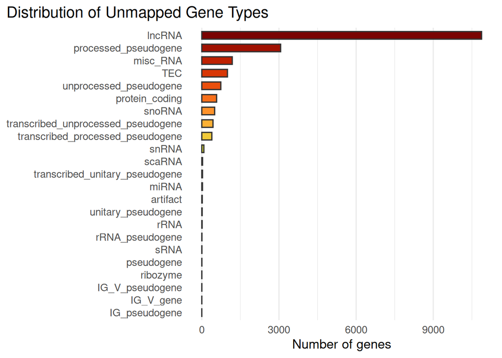

```r
library(ggplot2)

# Aggregating the gene types to get the number of unmapped genes that fall into
# each category
agg_gene_types <- aggregate(
  ensg_details$ensembl_gene_id,
  list(ensg_details$gene_biotype),
  FUN = function(x) length(unique(x))
)
# Ordering in descending order
agg_gene_types <- agg_gene_types[order(agg_gene_types$x),]

# Converting the groups into a factor so that ggplot respects the order
agg_gene_types$Group.1 <- factor(
  agg_gene_types$Group.1,
  levels = agg_gene_types$Group.1
)

ggplot2::ggplot(agg_gene_types, aes(x = Group.1, y = x, fill = Group.1)) +
  geom_col(width = 0.6, color = "grey20") +
  coord_flip() +
  scale_fill_viridis_d(option = "turbo", guide = "none") +
  labs(
    x = NULL, y = "Number of genes",
    title = "Distribution of Unmapped Gene Types"
  ) +
  theme_minimal(base_size = 13) +
  theme(
    plot.title.position = "plot",
    panel.grid.major.y = element_blank()
  )
```

**Figure 1** Number of genes for each type of gene not mapped to an HGNC symbol.

Since the assignment desired HUGO symbols for each row, all expression values that did not map to a HGNC symbol are discarded.

```r
# Discard all missing hgnc symbols.
gene_map <- gene_map[gene_map$hgnc_symbol != "",]
```

### 2.3.2 Explore genes mapped to multiple symbols

Next, we look into all ensembl ids that map to multiple HGNC symbols. There was only one gene that mapped to two different HGNC symbols (Table 5). and it was a long intergenic non-coding RNAs (lincRNAs)), I chose to keep the more detailed symbol based on online records, which ended up being `LINC00595`.

```r
# Get the number of unique hgnc per ensembl
dup_ensembl <- ave(
  gene_map$hgnc_symbol,
  gene_map$ensembl_gene_id,
  FUN = function(x) length(unique(x))
)

# subset rows where an Ensembl ID maps to >1 HGNC symbol
gene_map_multi <- gene_map[dup_ensembl > 1, ]

# Display the duplicate in a table.
gene_map_multi_display <- gene_map_multi
colnames(gene_map_multi_display) <- c("Ensembl ID", "HGNC Symbol")
rownames(gene_map_multi_display) <- NULL
rmarkdown::paged_table(gene_map_multi_display)
```

| Ensembl ID | HGNC Symbol |
| --- | --- |
| ENSG00000230417 | LINC00595 |
| ENSG00000230417 | LINC00856 |

**Table 5.** Ensembl ids that were mapped to multiple HGNC symbols

```r
# Removing LINC00856, I made sure that was the only ensembl id mapped
# to LINC00856
gene_map <- gene_map[gene_map$hgnc_symbol != "LINC00856",]
```

### 2.3.3 Explore genes mapped to the same variable

```r
# Get the number of unique ensembl per hgnc
dup_hgnc <- ave(
  gene_map$ensembl_gene_id,
  gene_map$hgnc_symbol,
  FUN = function(x) length(unique(x))
)

# subset rows where an HGNC symbol maps to >1 ensembl id
gene_map_multi <- gene_map[dup_hgnc > 1, ]
```

Finall, there were expression values that were not unique for specific genes; as in multiple Ensembl ids mapped to the same HUGO gene symbols. In Table 6, we see 19 pairs of Ensembl ids that had this property. To figure out what to do with them, I filtered for the expression profiles of these genes.

```r
# display the gene map table
gene_map_multi_display <- gene_map_multi[order(gene_map_multi$hgnc_symbol),]
colnames(gene_map_multi_display) <- c("Ensembl ID", "HGNC Symbol")
rownames(gene_map_multi_display) <- NULL
rmarkdown::paged_table(gene_map_multi_display)
```

| Ensembl ID | HGNC Symbol |
| --- | --- |
| ENSG00000214081 | CYP4F30P |
| ENSG00000282944 | CYP4F30P |
| ENSG00000225766 | DHRS4L1 |
| ENSG00000285467 | DHRS4L1 |
| ENSG00000206195 | DUXAP8 |
| ENSG00000271672 | DUXAP8 |
| ENSG00000224516 | ECEL1P2 |
| ENSG00000244280 | ECEL1P2 |
| ENSG00000149531 | FRG1BP |
| ENSG00000287288 | FRG1BP |

[output cut: 28 more lines]

**Table 6.** Ensembl ids that were mapped to the same HGNC symbol

We see in Table 7, most of the genes had one or zero genes with any expression. Only three genes had both, all of which had ensembl represent different splice variants of the same gene. Thus, I additively combined the expression profiles of each gene by hugo symbol assuming that these splice variants are not overlapping in counts.

```r
dup_gene_exp <- raw_counts_data %>% dplyr::right_join(gene_map_multi,
                              join_by("ensembl_id_trimmed" ==
                                               "ensembl_gene_id"))


dup_gene_exp_display <- dup_gene_exp[-1]
dup_gene_exp_display <- dup_gene_exp_display[c(7, 8, 1, 2, 3, 4, 5, 6)]
colnames(dup_gene_exp_display) <- c("Ensembl ID", "HGNC Symbol", "Control 1",
                                    "Control 2", "Control 3", "Mubritinib 1",
                                    "Mubritinib 2", "Mubritinib 3")
rmarkdown::paged_table(dup_gene_exp_display)
```

| Ensembl ID | HGNC Symbol | Control 1 | Control 2 | Control 3 | Mubritinib 1 | Mubritinib 2 | Mubritinib 3 |
| --- | --- | --- | --- | --- | --- | --- | --- |
| ENSG00000280498 | SNORA16A | 0 | 0 | 0 | 0 | 0 | 0 |
| ENSG00000274582 | SNORA16A | 0 | 0 | 0 | 0 | 0 | 0 |
| ENSG00000207421 | SNORD38B | 0 | 0 | 0 | 0 | 0 | 0 |
| ENSG00000281859 | SNORD38B | 0 | 0 | 0 | 0 | 0 | 0 |
| ENSG00000280466 | SCARNA4 | 0 | 0 | 0 | 0 | 0 | 0 |
| ENSG00000281394 | SCARNA4 | 0 | 0 | 0 | 0 | 0 | 0 |
| ENSG00000214081 | CYP4F30P | 0 | 0 | 0 | 0 | 0 | 0 |
| ENSG00000282944 | CYP4F30P | 0 | 0 | 0 | 0 | 0 | 0 |
| ENSG00000224516 | ECEL1P2 | 0 | 0 | 0 | 0 | 0 | 0 |
| ENSG00000244280 | ECEL1P2 | 0 | 0 | 0 | 0 | 0 | 0 |

[output cut: 28 more lines]

**Table 7.** Expression values for ensembl ids that mapped to the same HGNC symbol.

```r
# Combine the mappings with raw counts
mapped_counts_data <- raw_counts_data %>% dplyr::left_join(gene_map,
                                by = join_by("ensembl_id_trimmed" ==
                                               "ensembl_gene_id"))

# For all the genes with an hgnc, combine the rows with the same hgnc symbol
mapped_counts_data <- mapped_counts_data %>%
  dplyr::filter(!is.na(hgnc_symbol)) %>%
  dplyr::select(-ensembl_id_trimmed, -ensembl_id) %>%
  dplyr::group_by(hgnc_symbol) %>%
  dplyr::summarise(dplyr::across(where(is.numeric), sum), .groups = "drop")
```

## 2.4 Clean data

```r
library(edgeR)

# Reshift gene id column to rownames
gene_ids <- mapped_counts_data[1]
mapped_counts_data <- mapped_counts_data[-1]
rownames(mapped_counts_data) <- gene_ids$hgnc_symbol

groups <- sub("-.$", "", colnames(mapped_counts_data))

# Using DGEList to represent my data
DGE_data <- edgeR::DGEList(mapped_counts_data,
                           group = groups,
                           genes = gene_ids$hgnc_symbol)

keep <- edgeR::filterByExpr(DGE_data,
                            min.count = 10,
                            min.total.count = 15)
DGE_data <- DGE_data[keep, ]

mapped_counts_data_display <- DGE_data$counts
colnames(mapped_counts_data_display) <- c("Control 1", "Control 2", "Control 3",
              "Mubritinib 1", "Mubritinib 2", "Mubritinib 3")
rmarkdown::paged_table(as.data.frame(mapped_counts_data_display))
```

|  | Control 1 | Control 2 | Control 3 | Mubritinib 1 | Mubritinib 2 | Mubritinib 3 |
| --- | --- | --- | --- | --- | --- | --- |
| A1BG | 30 | 29 | 29 | 46 | 33 | 49 |
| A1BG-AS1 | 155 | 188 | 157 | 160 | 124 | 166 |
| A2M | 28 | 49 | 34 | 79 | 74 | 77 |
| A4GALT | 28 | 22 | 9 | 22 | 35 | 40 |
| AAAS | 3664 | 3890 | 4129 | 3637 | 3449 | 3650 |
| AACS | 1522 | 1545 | 1681 | 1643 | 1758 | 1760 |
| AADAT | 854 | 875 | 780 | 798 | 679 | 848 |
| AAGAB | 2721 | 3354 | 3429 | 3048 | 3212 | 3698 |
| AAK1 | 2062 | 2724 | 2666 | 3420 | 3389 | 3871 |
| AAMDC | 156 | 178 | 152 | 119 | 150 | 188 |

[output cut: 9990 more lines]

**Table 8.** Final clean raw counts data

There were no clear outliers in the dataset, as such I did not remove any. We will see clearer in the normalization step, but no counts were extreme outliers. I also do not believe removing outliers would be beneficial, as it could occlude real signal.

# 3. Normalize Data

```r
library(tidyr)
# Using TMM norm factors from edgeR for normalization
DGE_data <- edgeR::calcNormFactors(DGE_data, method = "TMM")
# Normalize on reads using cpm, non logged
norm_cpm <- edgeR::cpm(DGE_data, log = FALSE, prior.count = 1)


# Plotting read density in a box plot, logged to enhance visualization
plot_box <- function(data, title, ylabel = "log2(counts+1)") {
   df <- as.data.frame(data) %>%
    dplyr::mutate(gene = rownames(data)) %>%
    tidyr::pivot_longer(-gene, names_to = "sample", values_to = "value") %>%
    dplyr::mutate(value = log2(value + 1))

  ggplot2::ggplot(df, aes(x = sample, y = value)) +
    ggplot2::geom_boxplot(outlier.size = 0.2) +
    ggplot2::theme_bw() +
    ggplot2::theme(axis.text.x = element_text(angle = 90, vjust = 0.5, hjust = 1)) +
    ggplot2::labs(title = title, x = "Sample", y = ylabel)
}

# Plotting read density in a density plot, logged to enhance visualization
plot_density <- function(data, title, xlabel = "log2(counts+1)") {
   df <- as.data.frame(data) %>%
    dplyr::mutate(gene = rownames(data)) %>%
    pivot_longer(-gene, names_to = "sample", values_to = "value") %>%
    dplyr::mutate(value = log2(value + 1))

  ggplot2::ggplot(df, aes(x = value, color = sample)) +
    ggplot2::geom_density() +
    ggplot2::theme_bw() +
    ggplot2::labs(title = title, x = xlabel, y = "Density") +
    ggplot2::guides(colour = "none")
}
```

Normalization is important to make sure that the expression values we are comparing do not contain any technical variation that may skew the results. I chose to normalize based on `edgeR`’s TMM (Trimmed Mean of M-values) normalization, which calculates CPM not based off of just the raw library size, but a trimmed library size. This helps to make the normalization not skewed by genes with large counts, especially since I did not trim outliers.

EdgeR’s TMM ormalization makes the 25th-75th quantile much more consistent between samples (Figures 2, 4) and emphasizes the differences between lowly expressed genes and highly expressed genes (Figures 3, 5), showing a clearer biological signal.

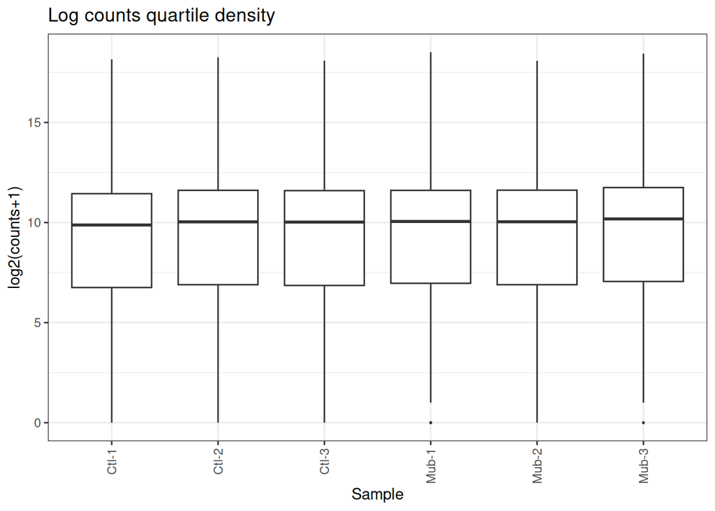

```r
# Plot the boxplot for unnormalized data
plot_box(DGE_data$counts, "Log counts quartile density")
```

**Figure 2** Box plot quartile density of unnormalized counts per sample. Counts logged to improve visualization

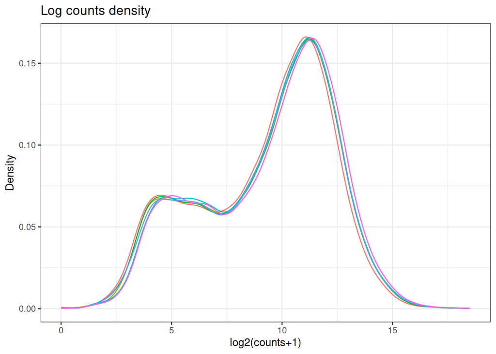

```r
# Plot the density plot for unnormalized data
plot_density(DGE_data$counts, "Log counts density")
```

**Figure 3** Line density plot of unnormalized counts per sample. Counts logged to improve visualization

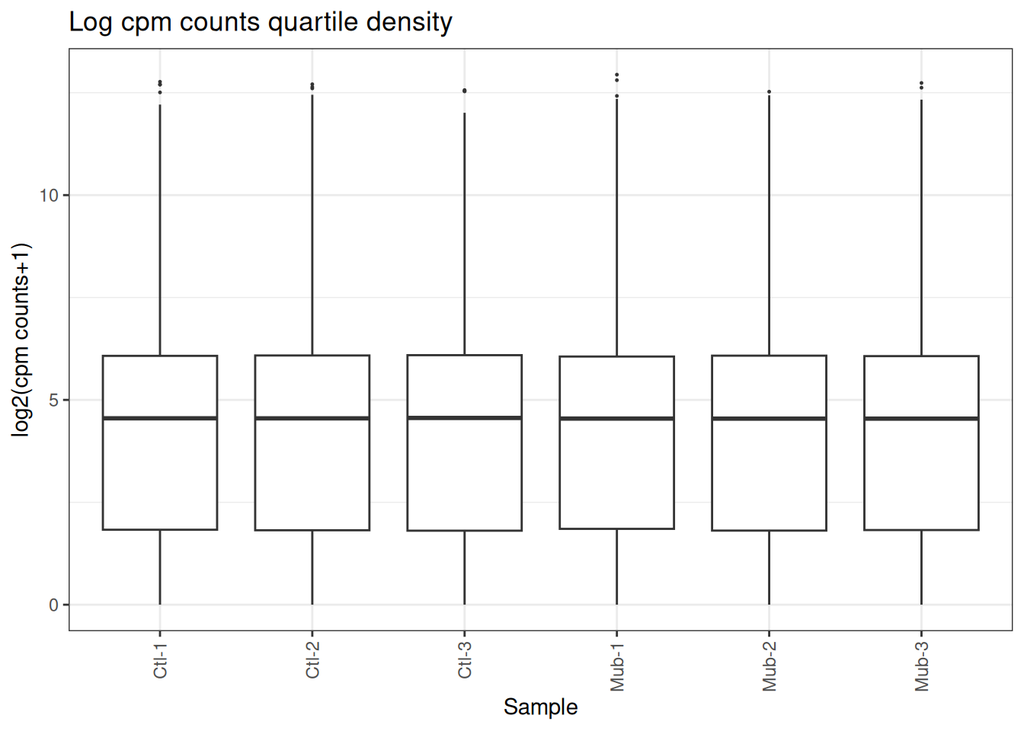

```r
# Plot the boxplot for TMM normalized data
plot_box(norm_cpm, title = "Log cpm counts quartile density",
         ylabel = "log2(cpm counts+1)")
```

**Figure 4** Box plot quartile density of TMM normalized counts per sample. Counts logged to improve visualization

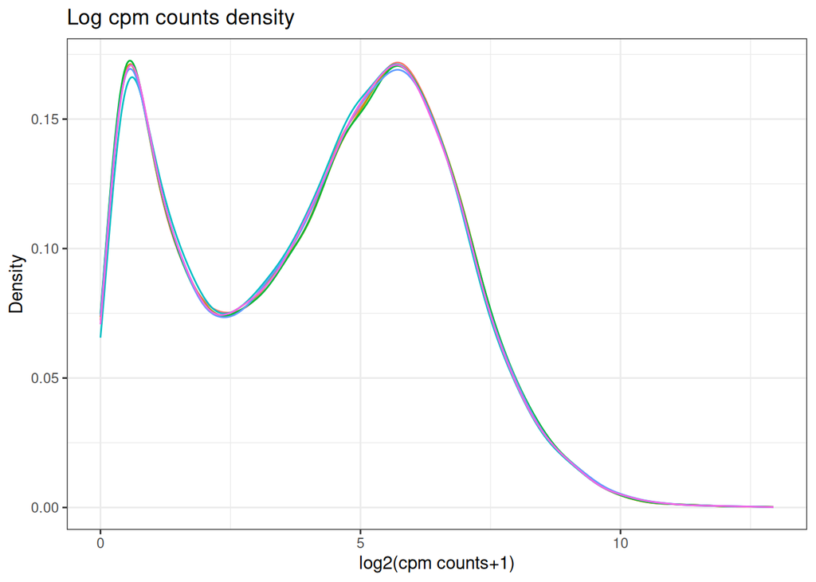

```r
# Plot the density plot for TMM normalized data
plot_density(norm_cpm, title = "Log cpm counts density",
             xlabel = "log2(cpm counts+1)")
```

**Figure 5** Line density plot of TMM normalized counts per sample. Counts logged to improve visualization

To make visualize the clustering of our samples, we plot a Multidimensional Scaling (MDS) plot (Figure 6). We can see a clear clustering within the two conditions, validating the experimental design.

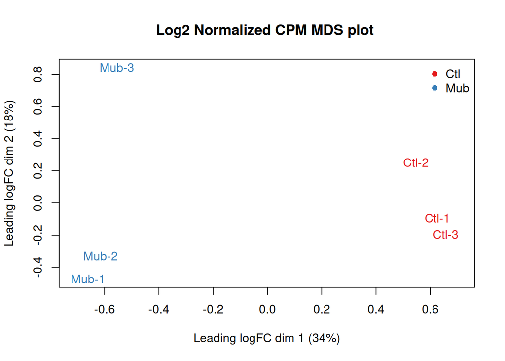

```r
library(RColorBrewer)
library(limma)
# Create an mds plot to visualize the sample clustering
colors <- RColorBrewer::brewer.pal(n = length(unique(DGE_data$samples$group)), "Set1")
limma::plotMDS(
  DGE_data,
  col = colors[DGE_data$samples$group],
  main = "Log2 Normalized CPM MDS plot "
)
legend("topright",
  legend = unique(DGE_data$samples$group),
  col = colors,
  pch = 16,
  bty = "n"
)
```

**Figure 6** The Multidimensional Scaling (MDS) plot for all 6 samples and their conditions.

```r
# Save final raw counts data and normalized counts data as specified in the assignment
saveRDS(as.data.frame(DGE_data$counts), "filtered_counts_data.rds")
saveRDS(as.data.frame(norm_cpm), "filtered_normalized_counts_data.rds")
```

# 4. Differential Expression

Now it is time to do differential expression! I will continue to use `edgeR`’s pipeline with `edgeR::glmQLFit`. The model design is used already defined by the `DGEList`’s group assignment. Since the experimental design is very clear, defining the factors is quite easy, as it is just the control vs mubritinib treatment.

To do final quality checks on the data, we look at the Biological Coefficient of Variation (BCV). Figure 7 shows that the data is clean and the experiment was well designed. The initial vairation is within moderate levels and it properly decreases as log CPM increases. This gives us confidence in the data quality again.

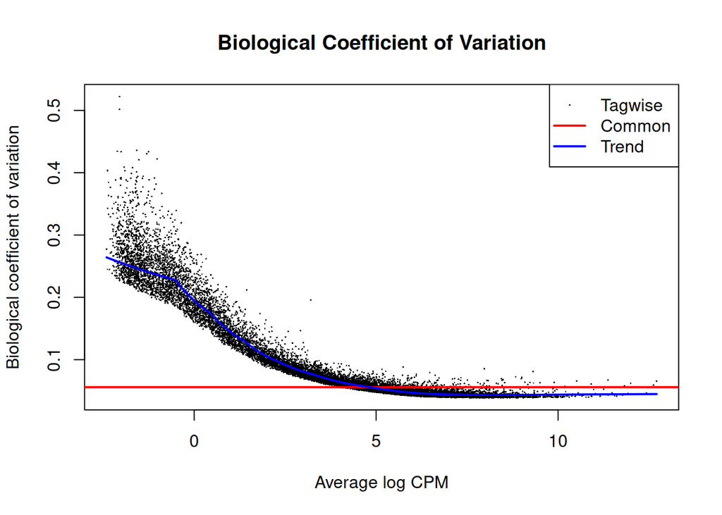

```r
# Create the dispersions and fit
# Design is specified by the group in DGE_data
disp <- edgeR::estimateDisp(DGE_data)
fit <- edgeR::glmQLFit(disp)
qlf <- edgeR::glmQLFTest(fit)

# Plotting the BCV
edgeR::plotBCV(disp, main = "Biological Coefficient of Variation")
```

**Figure 7** The Biological Coefficient of Variation (BCV) plot of the experimental data.

After performing QLF diffferential expression, the top genes were sorted on the False Discover Rate (FDR; Table 9). FDR is used to make sure that the p-values are corrected for how many tests we are doing. For example, since there are thousands of genes, it is likely that by chance some of them will be significant. Since `edgeR` calculates FDR automatically, I use that method for adjusting the p-value. Ultimately, `5160` genes pass the FDR threshold of `FDR < 0.05`.

```r
qlf_table <- edgeR::topTags(qlf, n = Inf)$table
pass_fdr_df <- qlf_table %>%
  mutate(sig = FDR < 0.05)

# Top differential genes displayed
qlf_display <- pass_fdr_df %>% dplyr::filter(sig == TRUE) %>% dplyr::select(-sig)
colnames(qlf_display) <- c("HGNC Symbol", "Log FC", "Log CPM", "F",
              "P Value", "FDR")
rownames(qlf_display) <- NULL
rmarkdown::paged_table(qlf_display)
```

| HGNC Symbol | Log FC | Log CPM | F | P Value | FDR |
| --- | --- | --- | --- | --- | --- |
| UNC5B | 1.7447110 | 6.455484702 | 1152.232679 | 6.720004e-19 | 5.423768e-15 |
| RRM2 | -1.4720992 | 7.857916525 | 1150.609647 | 6.812068e-19 | 5.423768e-15 |
| PDGFRA | -1.4711861 | 7.008420292 | 962.817074 | 3.795305e-18 | 2.014548e-14 |
| VGF | 1.6454779 | 9.578052266 | 911.938624 | 6.398114e-18 | 2.227142e-14 |
| WARS1 | 1.2208520 | 8.236417125 | 903.543151 | 6.993035e-18 | 2.227142e-14 |
| TRIB3 | 1.9295352 | 7.627766362 | 835.746711 | 1.479153e-17 | 3.925673e-14 |
| SESN2 | 1.4990887 | 7.074115497 | 734.474073 | 5.100028e-17 | 1.160184e-13 |
| AKNA | 1.3947875 | 6.054807735 | 690.435023 | 9.210892e-17 | 1.833428e-13 |
| PCK2 | 1.7237621 | 5.972731721 | 657.751313 | 1.463393e-16 | 2.589230e-13 |
| GFAP | 1.1730916 | 7.032380812 | 620.305158 | 2.558688e-16 | 4.074455e-13 |

[output cut: 5150 more lines]

**Table 9.** Significantly differentially expressed genes sorted based on False Discovery Rate (FDR).

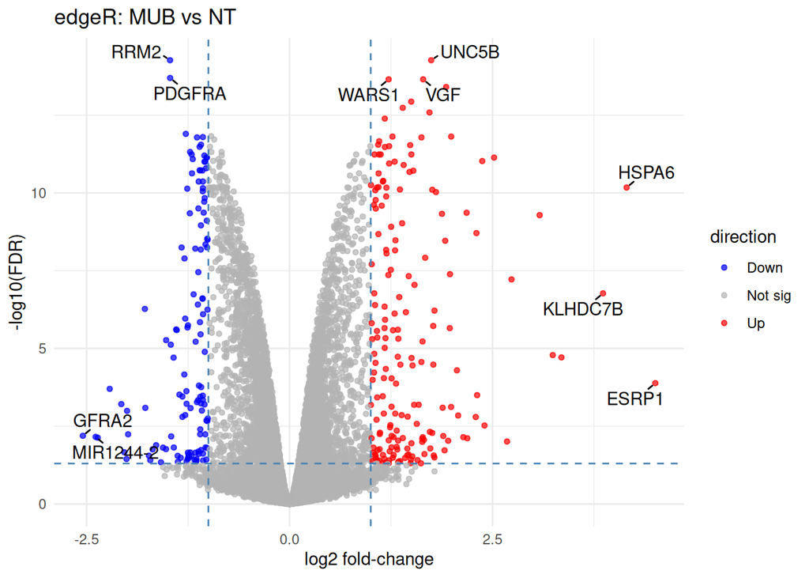

```r
library(ggrepel)
# Find genes to highlight, top 5 differentially expressed genes by FDR
# and top 5 differentially expressed genes by log FC.
genes_to_label <- c(head(pass_fdr_df, 5)[["genes"]],
                    head(pass_fdr_df[order(pass_fdr_df$logFC,
                                           decreasing=TRUE), ], 3)[["genes"]],
                    head(pass_fdr_df[order(pass_fdr_df$logFC,
                                           decreasing=FALSE), ], 2)[["genes"]])


# Set up the volcano plot data
volcano_table <- pass_fdr_df %>% dplyr::mutate(
  direction = case_when(
      FDR < 0.05 & logFC > 1 ~ "Up",
      FDR < 0.05 & logFC < -1 ~ "Down",
      TRUE ~ "Not sig"
    ),
  label = if_else(genes %in% genes_to_label, genes, NA)
)

ggplot2::ggplot(volcano_table, aes(x = logFC, y = -log10(FDR))) +
  ggplot2::geom_point(aes(color = direction), alpha = 0.7, size = 1.2) +
  ggrepel::geom_text_repel(
    aes(label = label),
    na.rm = TRUE,
    max.overlaps = Inf,
    box.padding = 0.3,
    point.padding = 0.2,
    min.segment.length = 0
  ) +
  ggplot2::scale_color_manual(values = c(
    "Up" = "red",
    "Down" = "blue",
    "Not sig" = "grey70"
  )) +
  ggplot2::geom_vline(xintercept = c(-1, 1), linetype = "dashed", color = "steelblue") +
  ggplot2::geom_hline(yintercept = -log10(0.05), linetype = "dashed", color = "steelblue") +
  ggplot2::theme_minimal() +
  ggplot2::labs(
    title = "edgeR: MUB vs NT",
    x = "log2 fold-change",
    y = "-log10(FDR)"
  )
```

**Figure 8** EdgeR volcano plot of differentially expressed genes between control and mubritinib conditions, significance requires FDR < 0.05 and an absolute log fold change > 1. Genes of interest were labeled.

Finally, we explore the heatmap of the expression values to find patterns and clusters between genes and samples. In Figure 9, we can see clear trends of upregularion and downregulation among the genes. The samples also cluster clearly together, providing more evidence to the well-made experimental design.

```r
# Filter for the genes with low FDR
log_cpm <- edgeR::cpm(DGE_data, log = TRUE, prior.count = 1)
keep <- pass_fdr_df$genes %in% rownames(log_cpm)

# Prep the data for a heat map
hm_mat <- log_cpm[pass_fdr_df$genes[keep], , drop = FALSE]
hm_labels <- pass_fdr_df$genes[keep]

# Making sure no labels repeat (HGNC symbols can repeat sometimes)
rownames(hm_mat) <- make.unique(hm_labels)

# Use the z-score in order to make the data symmetrical and easy to read.
hm_z <- t(scale(t(hm_mat)))
```

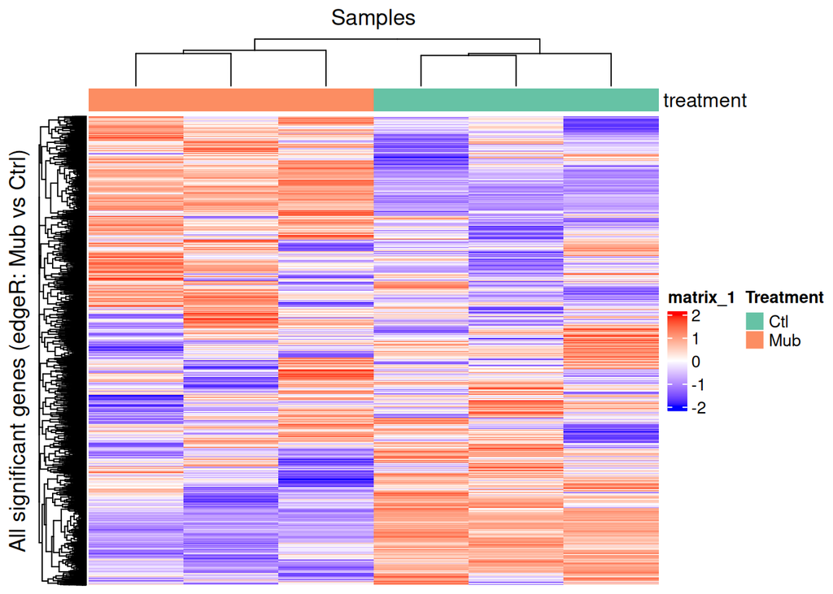

```r
library(ComplexHeatmap)

# Formatting the data for the heatmap
treatment_data <- as.factor(DGE_data$samples$group)
treat_levels <- levels(treatment_data)
treat_cols <- setNames(
  RColorBrewer::brewer.pal(max(2, length(treat_levels)), "Set2")[seq_along(treat_levels)],
  treat_levels
)

# Creating the complex heatmap annotation data
annot <- ComplexHeatmap::HeatmapAnnotation(
  treatment = treatment_data,
  col = list(
    treatment = treat_cols
  ),
  annotation_legend_param = list(
    treatment = list(title = "Treatment")
  )
)

color_function <- circlize::colorRamp2(c(-2, 0, 2), c("blue", "white", "red"))

ComplexHeatmap::Heatmap(
  hm_z,
  col = color_function,
  top_annotation = annot,
  show_row_names = FALSE,
  show_column_names = FALSE,
  cluster_rows = TRUE,
  cluster_columns = TRUE,
  row_title = paste0("All significant genes (edgeR: Mub vs Ctrl)"),
  column_title = "Samples"
)
```

**Figure 9** Heatmap of all signficantly differentiated genes, similarity clustered. They are separated based on sample, each sample is labeled by treatment (control or mubritinib).

Focusing on the top 20 genes allows us to make clearer interpretations (Figure 10). These genes are very clearly differentially expressed, with homogenous results among samples of the same treatment.

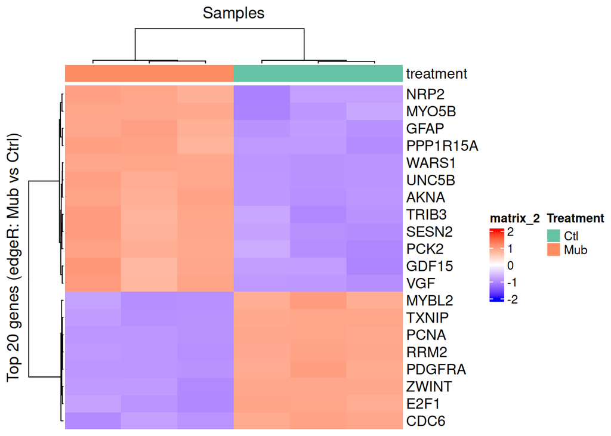

```r
# Displaying the top 20 differentially expressed genes to have a clearer picture
ComplexHeatmap::Heatmap(
  hm_z[1:20,],
  col = color_function,
  top_annotation = annot,
  show_row_names = TRUE,
  show_column_names = FALSE,
  cluster_rows = TRUE,
  cluster_columns = TRUE,
  row_title = paste0("Top ", 20, " genes (edgeR: Mub vs Ctrl)"),
  column_title = "Samples"
)
```

**Figure 10** Heatmap of the top 20 differentiated genes based on FDR, similarity clustered. They are separated based on sample, each sample is labeled by treatment (control or mubritinib).

# 5. Conclusion

Overall, this dataset is well-designed and is able to create a clear narrative of differential expression among treatments. The results indicate clearly the brain cancer origin, as the highest differentially expressed genes were mostly related to cancer or the brain. However, the clarity of if this treatment is improving the cancer is not yet clear. Some oncogenes are downregulated, but some oncogenes are upregulated. Perhaps closer analysis on gene set enrichment can elucidate larger scale patterns in the data, and provide a better story on the effects that mubritinib has on self-renewing brain tumour stem cells.

# 6. Questions

### Why is the dataset of interest to you?

This dataset came from a study testing the effects of mubritinib on Glioblastomas, one of the most treatment-resistant cancers. In particular, self-renewing brain tumour stem cells (BTSCs) cause a lot of problems for treatment. Finding cancer treatments is a very interesting and complicated subject. This study also tackles cancer in the brain, a more difficult area where tissue is sensitive to damage and drugs need to pass through the blood-brain barrier. Seeing another potential therapeutic drug for this difficult and impactful cancer is always amazing. Ultimately, the nature of the study in brain cancer and its role in proposing a new drug is what makes this dataset interesting to me.

### What are the control and test conditions of the dataset?

They performed a simple RNA-seq analysis on a patient derived BTSC. The control had no modification to the cell line, but the test condition exposed the cell to mubritinib. Specifically, they exposed the cell to a 24 h treatment with 500 nM of mubritinib.

### How many samples in each of the conditions of your dataset?

There were three samples of each condition: three controls and three mubritinib tests.

### Were there expression values that were not unique for specific genes? How did you handle these?

Yes, there were expression values that were not unique for specific genes, as in multiple ensembl ids mapped to the same HUGO gene symbols. Here, I explored the expression profiles of each. Most had one or zero genes with any expression. Only three genes had both, all of which had ensembl represent different splice variants of the same gene. Thus, I additively combined the expression profiles of each gene by hugo symbol.

If there were multiple Hugo symbols for a single ensembl (there was only one, and it was a long intergenic non-coding RNAs (lincRNAs)), I chose the more detailed symbol after some research.

### Were there expression values that could not be mapped to current HUGO symbols?

Yes, there were many expression values that could not be mapped to HUGO symbols. Most were lincRNAs, pseudogenes, or other transcripts we do not care about. However, some were protein coding genes that would be nice to have. Since the assignment desired HUGO symbols for each row, I discareded all expression values that did not map to a HUGO symbol.

### Were there any outliers in your dataset? How were they handled in the originating paper? How many outliers were removed?

There were no clear outliers in the dataset, gene-wise or sample-wise. All of them had expression values in reasonable ranges. No outliers were removed in the original paper. All I did was filter out lowly expressed genes.

### How did you handle replicates?

There were six samples, three controls and three test. Since it was a very simple experimental design, I separated these cleanly to be Control vs Mubritinib. There were no outlier samples to remove.

### What is the final coverage of your dataset?

At first, there were `61587`genes. Then, `18995` did not have a HUGO gene symbol. `38` genes mapped to duplicate HUGO symbols in a pairwise fashion. Then, thousands of genes were removed for being lowly expressed. This finally leaves `15924` total genes in the final dataset.

### Link to journal

https://github.com/bcb420-2026/Caleb_Ji/wiki/Assignment-1-%E2%80%90-Data-set-selection,-clean-and-scoring

# 7. References

Allaire, JJ, Yihui Xie, Christophe Dervieux, et al. 2025. *Rmarkdown: Dynamic Documents for r*. https://github.com/rstudio/rmarkdown.

Burban, Audrey, Cloe Tessier, Mathieu Larroquette, et al. 2025. “Exploiting Metabolic Vulnerability in Glioblastoma Using a Brain-Penetrant Drug with a Safe Profile.” *EMBO Mol. Med.* 17 (3): 469–503.

Chen, Yunshun, Lizhong Chen, Aaron T L Lun, Pedro Baldoni, and Gordon K Smyth. 2025. “edgeR V4: Powerful Differential Analysis of Sequencing Data with Expanded Functionality and Improved Support for Small Counts and Larger Datasets.” *Nucleic Acids Research* 53 (2): gkaf018. https://doi.org/10.1093/nar/gkaf018.

Davis, Sean, and Paul Meltzer. 2007. “GEOquery: A Bridge Between the Gene Expression Omnibus (GEO) and BioConductor.” *Bioinformatics* 14: 1846–47. https://doi.org/10.1093/bioinformatics/btm254.

Durinck, Steffen, Yves Moreau, Arek Kasprzyk, et al. 2005. “BioMart and Bioconductor: A Powerful Link Between Biological Databases and Microarray Data Analysis.” *Bioinformatics* 21: 3439–40.

Gu, Zuguang. 2022. “Complex Heatmap Visualization.” *iMeta*, ahead of print. https://doi.org/10.1002/imt2.43.

Neuwirth, Erich. 2022. *RColorBrewer: ColorBrewer Palettes*. https://doi.org/10.32614/CRAN.package.RColorBrewer.

Ritchie, Matthew E, Belinda Phipson, Di Wu, et al. 2015. “limma Powers Differential Expression Analyses for RNA-Sequencing and Microarray Studies.” *Nucleic Acids Research* 43 (7): e47. https://doi.org/10.1093/nar/gkv007.

Slowikowski, Kamil. 2024. *Ggrepel: Automatically Position Non-Overlapping Text Labels with ’Ggplot2’*. https://doi.org/10.32614/CRAN.package.ggrepel.

Wickham, Hadley. 2016. *Ggplot2: Elegant Graphics for Data Analysis*. Springer-Verlag New York. https://ggplot2.tidyverse.org.

Wickham, Hadley, Romain François, Lionel Henry, Kirill Müller, and Davis Vaughan. 2023. *Dplyr: A Grammar of Data Manipulation*. https://doi.org/10.32614/CRAN.package.dplyr.

Wickham, Hadley, Jim Hester, and Jennifer Bryan. 2025. *Readr: Read Rectangular Text Data*. https://doi.org/10.32614/CRAN.package.readr.

Wickham, Hadley, Davis Vaughan, and Maximilian Girlich. 2024. *Tidyr: Tidy Messy Data*. https://doi.org/10.32614/CRAN.package.tidyr.